# DS1 Final Presentation

## Gloria Li

# Problem Statement

## Does net-metered generation impact grid reliability?

[figure not shown]

Vox, 2019

## Outcomes

> System Average Interruption Duration Index (SAIDI)

> System Average Interruption Frequency Index (SAIFI)

> Customer Average Interruption Duration Index (CAIDI)

## Features (Original)

**Predictors**

> Net-metered distributed generation (wind, solar, other) – Megawatthours sold back

> Energy efficiency programs – Megawatthours sold back

> Demand response programs – Megawatthours sold back

**Controls**

> State, Utility Type, NERC Region, BA Code

> Utility sales and customer totals – Megawatthours sold

> Circuits and voltage optimization – number of circuits

# Methods: Feature Engineering

# Feature Engineering Part I: Missing Values

*To impute or not to impute?*

### Method 1

Impute with zeroes.

### Method 2

Drop the missing values.

### Outcome

I chose SAIDI as my outcome variable because it had the most non-missing entries.

# Feature Engineering Part II: New Variables

## Features (Created)

> Percentage of **net-metered solar**, **wind** and **total generation** out of **total sales**

> Percentage of **energy savings** out of **total sales**

> Percentage of **demand response savings** out of **total sales**

> Percentage of **demand response customers** out of **total customers**

# Methods: Visualization

[figure not shown]

# Methods: Modelling

# Modelling Part I: Transformation

### Dealing with Skewedness

> Four Methods: Log, Box-Cox, Sqrt, Median

### Dealing with Categorical Variables

> Dummy creation for NERC regions, state, and utility type

# Modelling Part II: Pipeline

### Choosing Predictors

> Examined correlation matrix to detect multicollinearity

### Choosing Models

> Hyperparameter tuning using GridSearchCV

> Preprocessing: Normalization

> Pipeline with Linear Model, K-Nearest Neighbors, Decision Tree, Bagged Regressor, and Random Forest

# Results

### Experiment 1:

Negative $R^2$, yikes!

### Experiment 2:

$R^2$ of 0.12

### Experiment 3:

$R^2$ of 0.42

# Results

[figure not shown]

# Lessons Learned (so far)

### Primary Challenges/Learning Opportunities

> *Iterative process:* Workflow Management (ML Flow)

> Skewed Data and Imputation

### Next Steps

> *Iterative process:* expand on ML pipeline with second missing value method and more data years, potentially with lagged features

> Create compelling and relevant visualizations

> Explore feature importance and back out insights even if model predictive accuracy stays low

# Works Cited

1. https://www.abb-conversations.com/2019/02/distributed-grid-management-101-ders-are-reshaping-the-power-grid/
2. https://www.vox.com/energy-and-environment/2018/11/30/17868620/renewable-energy-power-grid-architecture

When I used the median method from Attempt 1.5 these were my results. As reference, the standard deviation of my train_y is 146.39. So my mean squared error roughly reflects that, with the lowest RMSE coming out at 141.42.

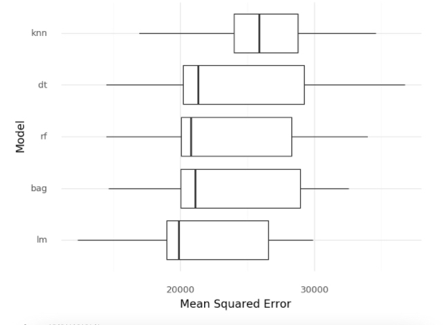

When I ran Attempt 1.5 through my untuned pipeline, I got these results, which were marginally better but not by much.

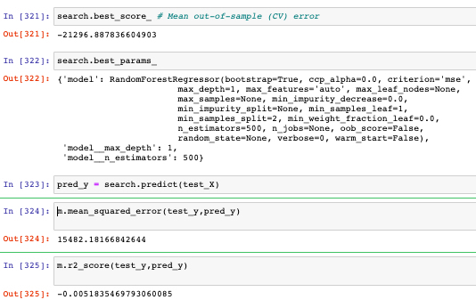

Attempt 2: My first positive R2 value thank god! But the MSE is still pretty bad.

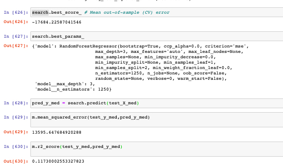